# MG205: Econometrics Theory and Applications

Empirical Exercise 3: Daughters and Legislative Voting

José Ignacio González-Rojas

j.i.gonzalez-rojas@lse.ac.uk

London School of Economics and Political Science

## Dick Cheney’s Daughter Changed His Vote

### A Conservative Republican Supports Gay Rights

#### Background

- Vice President under George W. Bush (2001-2009)
- Reliably conservative voting record
- Strong Republican party loyalty
- Expected to oppose LGBTQ rights

#### The Surprise

- Daughter Mary came out as lesbian
- Cheney broke with party on gay marriage
- Publicly supported same-sex relationships
- One of few Republicans to do so

Anecdote or systematic pattern? Can children influence parental ideology?

## Children May Influence Parental Beliefs on Policy Issues

### From Sociology to Political Economy

#### Sociological Evidence

- Parents with daughters hold more feminist views (Warner, 1991)
- Fathers of only daughters support gender equity policies (Warner & Steel, 1999)
- Effect strongest among educated, high-income parents

#### Do legislators with daughters vote more liberally on women’s issues (Washington, 2008)?

❗ **How do we establish causation?**

- Maybe liberals choose to have more children?
- Maybe progressive people are more likely to have daughters?

# Establishing Random Assignment

## Child Gender Must Be Random for Causal Inference

### The Identification Challenge

#### What We Need

- Random assignment of daughters
- No selection into treatment
- Valid control group

#### What Could Go Wrong

- **China/India**: Strong son preference
  - Selective abortion creates bias
  - Gender correlated with parental characteristics
  - Cannot use for causal inference
- **US Context**: Need to verify randomness

Without randomisation, we cannot separate causation from correlation

## Child Gender Is Random in the United States

### Balance Tests Show No Selection Bias

[figure not shown]

Balance tests across legislator characteristics

## US Legislators Have Approximately 50% Daughters

### Descriptive Statistics on Family Composition

#### Average Family Size

- **Mean children**: 2.5
- **Mean daughters**: 1.3
- **Mean sons**: 1.2

**Sample**: 434 US House Representatives, 105th Congress (1997-1998)

#### Gender Distribution

- **Proportion daughters**: 52%
- **Expected under randomness**: 50%
- Cannot reject equality ($p = 0.22$)

Child gender operates like nature’s randomised experiment

# The Naive Approach Fails

## Regressing on Daughters Without Controls Gives Wrong Answer

### $\text{NOW}_{i} = \beta_0 + \beta_1 \cdot \text{daughters}_i + e_i$

- $\hat{\beta}_1 = -2.1$ points per daughter

This suggests daughters make legislators MORE conservative!

**But this contradicts:**

- Our theoretical prediction
- The sociological evidence
- The Dick Cheney story

**What’s going wrong?**

## Omitting Total Children Creates Confounding

### The Causal Structure Reveals the Problem

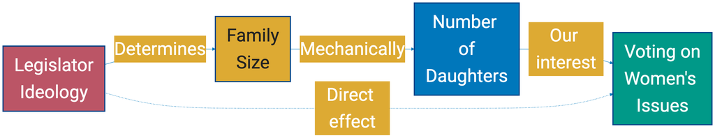

Conservatives have larger families → More daughters → Negative correlation

## Ideology Correlates with Family Size in Our Sample

### The Confounding Mechanism

#### Republicans Have More Children

- **Republicans**: 2.6 children on average
- **Democrats**: 2.4 children on average
- **Difference**: Modest but systematic

#### Republicans Vote More Conservatively

- **Republicans**: 12.0 NOW score
- **Democrats**: 73.1 NOW score
- **Difference**: 61 points

More children → More daughters → Conservatives have more daughters

This creates spurious negative correlation between daughters and liberal voting

# Control for Total Children

## Within Family Size Comparisons Isolate Daughter Effect

### Two Children Example Shows Clear Pattern

[figure not shown]

Mean NOW scores by family composition - 2 children

Democrats and Republicans both show increasing NOW scores with more daughters

## Pattern Persists for Three Children Families

### Consistent Gradient Within Each Party

[figure not shown]

Mean NOW scores by family composition - 3 children

More daughters → More liberal voting, holding total children constant

## Controlling for Total Children Reveals Positive Effect

### Omitting total children creates large omitted variable bias

[figure not shown]

Coefficient on daughters across model specifications

Sign flips from negative to positive when controlling for family size

## Each Additional Daughter ⬆️ Liberal Voting by 2.7 Points

### $\text{NOW}_i = \beta_0 + \beta_1 \cdot \text{daughters}_i + \beta_2 \cdot \text{total \# children}_i + \mathbf{X}_i\boldsymbol{\beta} + e_i$

**430 legislators**. Controls: race, religion, age, service length

| Variable | Coefficient | Std. Error | p-value |
| --- | --- | --- | --- |
| **Number of daughters** | **2.72** | **(1.05)** | **0.010** |
| Total children | -2.83 | (0.76) | 0.000 |
| Republican | -44.87 | (2.11) | 0.000 |
| Female | 10.83 | (2.69) | 0.000 |
| Democratic vote share | 84.16 | (10.87) | 0.000 |

## Economic Magnitude Is Meaningful

### Contextualising the 2.7 Point Effect

#### Benchmarks for Comparison

- **Male-Female gap**: 10.8 points
- **Effect of one daughter**: 2.7 points
- **Ratio**: 25% of gender gap

#### Interpretation

- Each daughter ≈ one-quarter the effect of legislator being female
- Cumulative effect substantial:
  - 3 daughters vs 0 daughters: **8.1 points**
  - About 75% of the gender gap

Economically significant effect, not just statistically significant

# Treatment Heterogeneity

## Male Legislators Show Stronger Response to Daughters

### Differential Effects by Gender and Party

[figure not shown]

Heterogeneous treatment effects across subgroups

Effect concentrated among male legislators and Democrats

## Males More Likely to Update Beliefs from Daughter Experience

### Theoretical Explanation for Heterogeneity

#### Why Males Show Stronger Effects

- **Female legislators**: Already exposed to women’s issues firsthand
- **Male legislators**: Daughters provide new perspective
  - First direct experience with gender discrimination
  - Empathy through family member
  - Update priors more dramatically

#### Why Democrats Show Effects

- **Democrats**: More freedom to vote ideology
  - Less party pressure on moral issues
  - Can respond to personal experiences
- **Republicans**: Strong party discipline
  - Harder to break from party line
  - Though effect still positive (1.9 points)

# Robustness: Multiple Measures

## Effect Consistent Across Three Voting Indices

### Different Organizations Weight Issues Differently

[figure not shown]

Robustness across NOW, AAUW, and RTL voting scores

All three measures significant at 5% level

## Three Indices Capture Different Aspects of Women’s Issues

### Measurement Strategy Builds Confidence

| Index | Organization | Focus | Effect | p-value |
| --- | --- | --- | --- | --- |
| **NOW** | National Organization for Women | 20 pieces of legislation | **2.72** | **0.010** |
| **AAUW** | American Association of University Women | 8 focused issues | **2.63** | **0.019** |
| **RTL** | National Right to Life Committee | Reproductive rights (reversed) | **4.01** | **0.010** |

Consistent positive effects rule out measurement artifact

## Reproductive Rights Show Strongest Effects

### Issue Area Analysis

#### Why Reproductive Rights?

1. **Uniquely female issue**: Directly affects daughters
2. **Moral dimension**: Less party pressure
3. **Personal salience**: Fathers consider daughter’s future

#### Evidence

- **RTL coefficient**: 4.0 (largest effect)
- **Significance**: $p = 0.010$
- **Interpretation**: Each daughter increases liberal voting on abortion/contraception by 4 points

## What We Have Learned Today

### Five Key Lessons on Natural Experiments and Causal Inference

1. **Random assignment enables causal inference**
   - Child gender is random in US (unlike China/India)
   - Balance tests verify no selection bias
2. **Proper controls are essential**
   - Naive regression gives wrong sign
   - Controlling for total children reveals positive effect
3. **Economic magnitude matters**
   - 2.7 points = 25% of male-female gap
4. **Treatment effects are heterogeneous**
   - Stronger for males and Democrats
   - Supports mechanism: updating beliefs from experience
5. **Multiple measures build robustness**
   - Consistent across NOW, AAUW, RTL
   - Strongest for reproductive rights

# Next Week

## Statistical Inference in Practice

### From Estimation to Testing

1. **Hypothesis testing framework**
   - Null vs alternative hypotheses
   - t-statistics and p-values
   - Type I and Type II errors
2. **Confidence intervals**
   - Construction and interpretation
   - Relationship to hypothesis tests
3. **Joint hypothesis testing**
   - F-tests for multiple restrictions
   - Testing economic theories with data
   - When individual tests aren’t enough

# References

## References

Warner, R. L. (1991). Does the Sex of Your Children Matter? Support for Feminism among Women and Men in the United States and Canada. *Journal of Marriage and the Family*, *53*(4), 1051. https://doi.org/10.2307/353008

Warner, R. L., & Steel, B. S. (1999). CHILD REARING AS A MECHANISM FOR SOCIAL CHANGE: The Relationship of Child Gender to Parents’ Commitment to Gender Equity. *Gender & Society*, *13*(4), 503–517. https://doi.org/10.1177/089124399013004005

Washington, E. L. (2008). Female Socialization: How Daughters Affect Their Legislator Fathers’ Voting on Women’s Issues. *American Economic Review*, *98*(1), 311–332. https://doi.org/10.1257/aer.98.1.311